# Timecourse TTseq2

```r
library( tidyverse )
```

```r
source( "~/Script repository/R scripting/Matrix_Fns.R" ) #5/2/23 commit at my github https://github.com/McK-Ford/Script-repository/blob/main/R%20scripting/Matrix.R
```

```r
prox <- read.delim(
  file = "C:/Users/kayle/Box/Vertinolab/McKayla Ford/Projects/R-loops_Pausing/Sequence_based_analysis/Classing_by_Skew/beds/prox_tss_order.bed",
  header = FALSE
  )
dist <- read.delim(
  file = "C:/Users/kayle/Box/Vertinolab/McKayla Ford/Projects/R-loops_Pausing/Sequence_based_analysis/Classing_by_Skew/beds/dist_cgi_order.bed",
  header = FALSE
  )
```

Because I was dumb and took the labels off when I made these originally:

```r
gene_info <- rbind( prox, dist )
colnames( gene_info ) <- c( "uniq_id", "chrom", "cpg_s", "cpg_e",
                            "cpg_num", "gene_s", "gene_e",
                            "strand", "name", "ex2in", "gene_l",
                            "cpg_l", "TSS_3prime", "prime5_TSS",
                            "TSS_ex", "TSS_skew", "CGI3_skew",
                            "TES_skew", "CGI5_skew", "x2in_skew",
                            "simple_skew_class")
```

Bed filtering 1

```r
gene_info_p <- gene_info |> filter( strand == "+" & chrom != "chrX" )
gene_info_m <- gene_info |> filter( strand == "-" & chrom != "chrX" )
```

Let’s skip the scaled stuff for now. I’m not sure what josh/wendy did to make them match up, because I’ve checked the numbers, I’ve literally counted reads in IGV. So all I want is TSS-centered and 3’ CGI centered.

```r
TSS_CGI_E_prox_p <- gene_info_p |>
  filter(simple_skew_class=="Prox") |>
  select( c("chrom", "gene_s", "cpg_e", "uniq_id", "TSS_skew", "strand") )
TSS_CGI_E_prox_m <- gene_info_m |>
  filter(simple_skew_class=="Prox") |>
  select( c("chrom",  "cpg_s", "gene_e", "uniq_id", "TSS_skew", "strand") )

TSS_CGI_E_dist_p <- gene_info_p |>
  filter(simple_skew_class=="Dist") |>
  select( c("chrom", "gene_s", "cpg_e", "uniq_id", "TSS_skew", "strand") )
TSS_CGI_E_dist_m <- gene_info_m |>
  filter(simple_skew_class=="Dist") |>
  select( c("chrom",  "cpg_s", "gene_e", "uniq_id", "TSS_skew", "strand") )
```

```r
tab_ls <- list(
  TSS_CGI_E_prox_p,
  TSS_CGI_E_prox_m,
  TSS_CGI_E_dist_p,
  TSS_CGI_E_dist_m
)
for (i in seq_along( tab_ls ) ) {
  colnames( tab_ls[[i]] ) <- c(
    "chrom",
    "start",
    "end",
    "uniq_id",
    "score",
    "strand"
    )
}
```

```r
TSS_tab <- list(rbind(tab_ls[[1]], tab_ls[[2]]), rbind(tab_ls[[3]], tab_ls[[4]]))
tmp_ls <- tab_ls
tmp_ls[[1]]$start <- tmp_ls[[1]]$end - 1
tmp_ls[[1]]$end <- tmp_ls[[1]]$start + 1
tmp_ls[[3]]$start <- tmp_ls[[3]]$end - 1
tmp_ls[[4]]$end <- tmp_ls[[4]]$start + 1
CGI_tab <- list(rbind(tmp_ls[[1]], tmp_ls[[2]]), rbind(tmp_ls[[3]], tmp_ls[[4]]))
```

```r
DIR <- "C:/Users/kayle/Box/Vertinolab/McKayla Ford/Data/NascentSeq/PublicData/GSE173374_Polenkowski_2021_HEK293T_TTseq/Bigwigs/"
BWs <- list(
  paste0(
    DIR,
    "GSM6257288_TT-seq_shCtrl_10min.bigwig"
    ),
  paste0(
    DIR,
    "GSM6257289_TT-seq_shCtrl_20min.bigwig"
    ),
  paste0(
    DIR,
    "GSM6257290_TT-seq_shCtrl_30min.bigwig"
    ),
  paste0(
    DIR,
    "GSM6257291_TT-seq_shCtrl_40min.bigwig"
    ),
  paste0(
    DIR,
    "GSM6257292_TT-seq_shTHOC5_10min.bigwig"
    ),
  paste0(
    DIR,
    "GSM6257293_TT-seq_shTHOC5_20min.bigwig"
    ),
  paste0(
    DIR,
    "GSM6257294_TT-seq_shTHOC5_30min.bigwig"
    ),
  paste0(
    DIR,
    "GSM6257295_TT-seq_shTHOC5_40min.bigwig"
    )
)
```

```r
TSS_LoL <- rep( list( vector( mode = "list", length = 8 ) ), 4 )
for ( bed in seq_along( TSS_tab ) ) {
  for ( bw in seq_along( BWs ) ) {
    TSS_LoL[[bed]][[bw]] <- score_matrix(
      bed = TSS_tab[[bed]],
      readsource = BWs[[bw]],
      b = 1000,
      a = 3000,
      bs = 10,
      ignorestrand = TRUE,
      method = "single_anch",
      bam_or_bw = "bw"
      )
  }
}
```

```r
CGI_LoL <- rep( list( vector( mode = "list", length = 8 ) ), 4 )
for ( bed in seq_along( CGI_tab ) ) {
  for ( bw in seq_along( BWs ) ) {
    CGI_LoL[[bed]][[bw]] <- score_matrix(
      bed = CGI_tab[[bed]],
      readsource = BWs[[bw]],
      b = 1000,
      a = 3000,
      bs = 10,
      ignorestrand = TRUE,
      method = "single_anch",
      bam_or_bw = "bw"
      )
  }
}
```

```r
TSS_LoL2 <- TSS_LoL
CGI_LoL2 <- CGI_LoL
for ( bed in seq_along( TSS_tab ) ) {
  for ( bw in seq_along( BWs ) ) {
        long_tab <- melt(TSS_LoL2[[bed]][[bw]], na.rm=TRUE, id.vars = c("uniq_id", "chrom", "start", "end", "score", "strand"))
    TSS_LoL2[[bed]][[bw]] <- long_tab[, .(mean_score = mean(value)), by = list(variable)]
    TSS_LoL2[[bed]][[bw]]$site <- "TSS"
    TSS_LoL2[[bed]][[bw]]$variable <- as.numeric(TSS_LoL2[[bed]][[bw]]$variable)
  }
}

for ( bed in seq_along( CGI_tab ) ) {
  for ( bw in seq_along( BWs ) ) {
        long_tab <- melt(CGI_LoL2[[bed]][[bw]], na.rm=TRUE, id.vars = c("uniq_id", "chrom", "start", "end", "score", "strand"))
    CGI_LoL2[[bed]][[bw]] <- long_tab[, .(mean_score = mean(value)), by = list(variable)]
    CGI_LoL2[[bed]][[bw]]$site <- "CGI"
    CGI_LoL2[[bed]][[bw]]$variable <- as.numeric(CGI_LoL2[[bed]][[bw]]$variable)
  }
}
```

```r
prox_tss <- TSS_LoL2[[1]]
dist_tss <- TSS_LoL2[[2]]

prox_cgi <- CGI_LoL2[[1]]
dist_cgi <- CGI_LoL2[[2]]
```

```r
for (i in seq_along(prox_tss)){ prox_tss[[i]]$class <- "prox" }
for (i in seq_along(dist_tss)){ dist_tss[[i]]$class <- "dist" }
for (i in seq_along(prox_cgi)){ prox_cgi[[i]]$class <- "prox" }
for (i in seq_along(dist_cgi)){ dist_cgi[[i]]$class <- "dist" }
```

```r
ctrl10tss <- rbind(prox_tss[[1]], dist_tss[[1]])
ctrl10tss$time <- 10

ctrl10cgi <- rbind(prox_cgi[[1]], dist_cgi[[1]])
ctrl10cgi$time <- 10

ctrl20tss <- rbind(prox_tss[[2]], dist_tss[[2]])
ctrl20tss$time <- 20

ctrl20cgi <- rbind(prox_cgi[[2]], dist_cgi[[2]])
ctrl20cgi$time <- 20

ctrl30tss <- rbind(prox_tss[[3]], dist_tss[[3]])
ctrl30tss$time <- 30

ctrl30cgi <- rbind(prox_cgi[[3]], dist_cgi[[3]])
ctrl30cgi$time <- 30

ctrl40tss <- rbind(prox_tss[[4]], dist_tss[[4]])
ctrl40tss$time <- 40

ctrl40cgi <- rbind(prox_cgi[[4]], dist_cgi[[4]])
ctrl40cgi$time <- 40

ctrltss <- rbind(ctrl10tss, ctrl20tss, ctrl30tss, ctrl40tss)
ctrltss$condition <- "ctrl"

ctrlcgi <- rbind(ctrl10cgi, ctrl20cgi, ctrl30cgi, ctrl40cgi)
ctrlcgi$condition <- "ctrl"
```

```r
thoc510tss <- rbind(prox_tss[[5]], dist_tss[[5]])
thoc510tss$time <- 10

thoc510cgi <- rbind(prox_cgi[[5]], dist_cgi[[5]])
thoc510cgi$time <- 10

thoc520tss <- rbind(prox_tss[[6]], dist_tss[[6]])
thoc520tss$time <- 20

thoc520cgi <- rbind(prox_cgi[[6]], dist_cgi[[6]])
thoc520cgi$time <- 20

thoc530tss <- rbind(prox_tss[[7]], dist_tss[[7]])
thoc530tss$time <- 30

thoc530cgi <- rbind(prox_cgi[[7]], dist_cgi[[7]])
thoc530cgi$time <- 30

thoc540tss <- rbind(prox_tss[[8]], dist_tss[[8]])
thoc540tss$time <- 40

thoc540cgi <- rbind(prox_cgi[[8]], dist_cgi[[8]])
thoc540cgi$time <- 40

thoc5tss <- rbind(thoc510tss, thoc520tss, thoc530tss, thoc540tss)
thoc5tss$condition <- "thoc5"

thoc5cgi <- rbind(thoc510cgi, thoc520cgi, thoc530cgi, thoc540cgi)
thoc5cgi$condition <- "thoc5"
```

```r
tss <- rbind(ctrltss, thoc5tss)
cgi <- rbind(ctrlcgi, thoc5cgi)
```

```r
mytheme <- theme(
  panel.background = element_rect( fill = "white" ),
  text = element_text( color = "black", face = "bold", family = "sans" ),
  axis.text = element_text( color = "black" ),
  axis.ticks = element_line( color = "black" ),
  plot.margin = unit( c( 0.25, 0.25, 0.25, 0.25 ), "cm" ),
  plot.title = element_text( vjust = 2 ),
  panel.grid.major = element_blank(),
  panel.grid.minor = element_blank(),
  axis.title.y = element_text( vjust = 0 ),
  axis.title.x = element_text( vjust = 0 ),
  panel.border = element_blank(),
  axis.line = element_line()
)
```

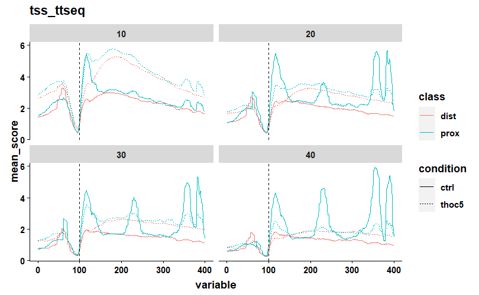

```r
geom_tt_tss <- tss |> ggplot( aes( x = variable, y = mean_score, color = class, linetype = condition)) +
      geom_line() +
      mytheme +
      ggtitle(label="tss_ttseq") +
  facet_wrap(~time) +
  geom_vline(xintercept = 100, linetype = "dashed", color = "Black")
geom_tt_tss
```

…what.

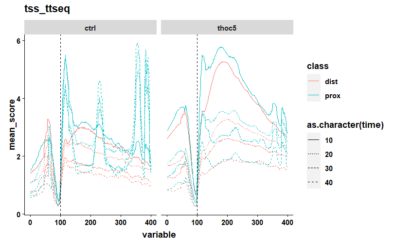

```r
geom_tt_tss2 <- tss |> ggplot( aes( x = variable, y = mean_score, color = class, linetype = as.character(time))) +
      geom_line() +
      mytheme +
      ggtitle(label="tss_ttseq") +
  facet_wrap(~condition) +
  geom_vline(xintercept = 100, linetype = "dashed", color = "Black")
geom_tt_tss2
```

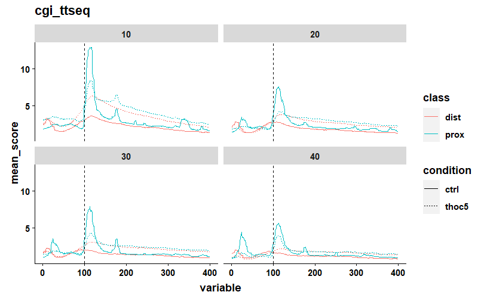

```r
geom_tt_cgi <- cgi |> ggplot( aes( x = variable, y = mean_score, color = class, linetype = condition)) +
      geom_line() +
      mytheme +
      ggtitle(label="cgi_ttseq") +
  facet_wrap(~time) +
  geom_vline(xintercept = 100, linetype = "dashed", color = "Black")
geom_tt_cgi
```

Well that raises a lot more questions than it answers… I just double checked, everything is what I think it is.

Ohhh wait wait wait. Stop paying attention to the overall shape. So. Thoc5 is supposed to be a r-loop resolver. R-loops are theoretically lower where skew is lower. Low skew in prox. Prox thoc5 ko is lower than control, while dist is higher than control!!! Tss harder to observe. dist, thoc5 ko always higher than control, same as high skew at 3’ cgi result, but prox also higher than control at 10 min, then can’t say after that as it ‘flattens out’ so lower in some spots higher in others.